# Reproducible Research: Peer Assessment 1

## Loading and preprocessing the data

The data is loaded using the read.csv() function (and the firste few lines are shown).

```r
activity <- read.csv("activity/activity.csv")
head(activity)
```

```
##   steps       date interval
## 1    NA 2012-10-01        0
## 2    NA 2012-10-01        5
## 3    NA 2012-10-01       10
## 4    NA 2012-10-01       15
## 5    NA 2012-10-01       20
## 6    NA 2012-10-01       25
```

## What is mean total number of steps taken per day?

The step data is aggregated by date and a histogram is plotted.

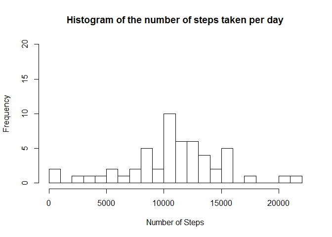

```r
SumSteps <- aggregate(.~date, data = activity[,c(1,2)], sum)
hist(SumSteps$steps,main = "Histogram of the number of steps taken per day",breaks=20,xlab = "Number of Steps",ylim = c(0,20))
```

The mean and median is then calculated.

```r
MeanSteps <- mean(SumSteps$steps)
MedianSteps <- median(SumSteps$steps)
```

The mean number of steps per day is 10766.19.  
The median number of steps per day is 10765.

## What is the average daily activity pattern?

The step data is aggregated by the 5-min interval identifier and the daily pattern is plotted.

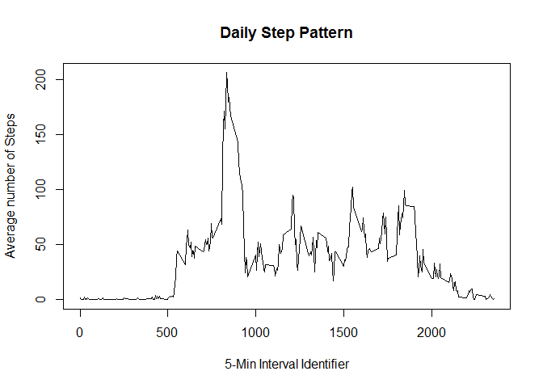

```r
Avg5MinInt <- aggregate(.~interval, data = activity[,c(1,3)], mean)
plot(y=Avg5MinInt$steps,x=paste( Avg5MinInt$interval),type="l", xlab = "5-Min Interval Identifier",ylab = "Average number of Steps")
title("Daily Step Pattern")
```

The 5-min interval with the maximum average number of steps is then determined.

```r
MaxDailyPattern <- Avg5MinInt$interval[ which.max(Avg5MinInt$steps) ]
```

## Imputing missing values

The number of NA records are determined

```r
NA_Count <- sum(is.na(activity$steps))
```

The total number of NA records are 2304.

The NA records are replaced with the average for that 5-Min interval (in a new dataframe called “activity2”).

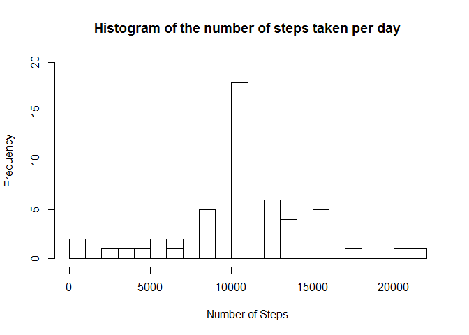

```r
activity2 <- activity
for (i in 1:nrow(activity2[is.na(activity$steps),])){
  activity2[is.na(activity$steps),][i,1]<-
    Avg5MinInt[Avg5MinInt$interval == activity2[is.na(activity$steps),][i,3],2]
}

SumSteps2 <- aggregate(.~date, data = activity2[,c(1,2)], sum)
hist(SumSteps2$steps,main = "Histogram of the number of steps taken per day",breaks=20,xlab = "Number of Steps", ylim = c(0,20))
```

```r
MeanSteps2 <- mean(SumSteps2$steps)
MedianSteps2 <- median(SumSteps2$steps)
```

## Are there differences in activity patterns between weekdays and weekends?

A weekday/weekend factor variable is added to the dataframe (“activity2”)

```r
activity2$DayType <- "weekday"
activity2[weekdays(as.POSIXct(activity2$date)) %in% c("Saturday","Sunday"),]$DayType <- "weekend"
```

The step data is aggregated by the 5-min interval identifier for weekdays and weekends and their daily pattern is plotted.

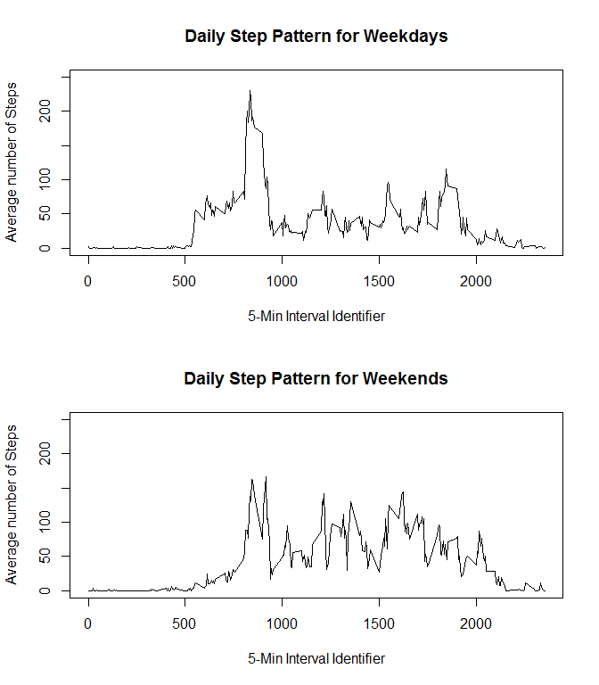

```r
Avg5MinInt2_weekday <- aggregate(.~interval, data = activity2[activity2$DayType=="weekday",c(1,3)], mean)
Avg5MinInt2_weekend <- aggregate(.~interval, data = activity2[activity2$DayType=="weekend",c(1,3)], mean)

par(mfrow = c(2, 1))
    plot(y=Avg5MinInt2_weekday$steps,x=paste( Avg5MinInt2_weekday$interval),type = "l", xlab = "5-Min Interval Identifier",ylim = c(0,250),ylab = "Average number of Steps")
    title("Daily Step Pattern for Weekdays")
    plot(y=Avg5MinInt2_weekend$steps,x=paste( Avg5MinInt2_weekend$interval),type = "l", xlab = "5-Min Interval Identifier",ylim = c(0,250),ylab = "Average number of Steps")
    title("Daily Step Pattern for Weekends")
```